# **A Glimpse Into The 2024 Stack Overflow Survey: Insights and Analysis**

### Plot 2: Professional vs. Non-Professional Highest Education Level Attained

This plot explores the `ed_level` variable against the `main_branch` variable and aims to see if one’s education level factors in to whether they are a professional developer or not. We believe a **heatmap** is ideal for exploring the relationship between these two variables as it allows us to visualise the percentage breakdowns of each person’s highest education level across the different levels of professionalism identified in `main_branch`.

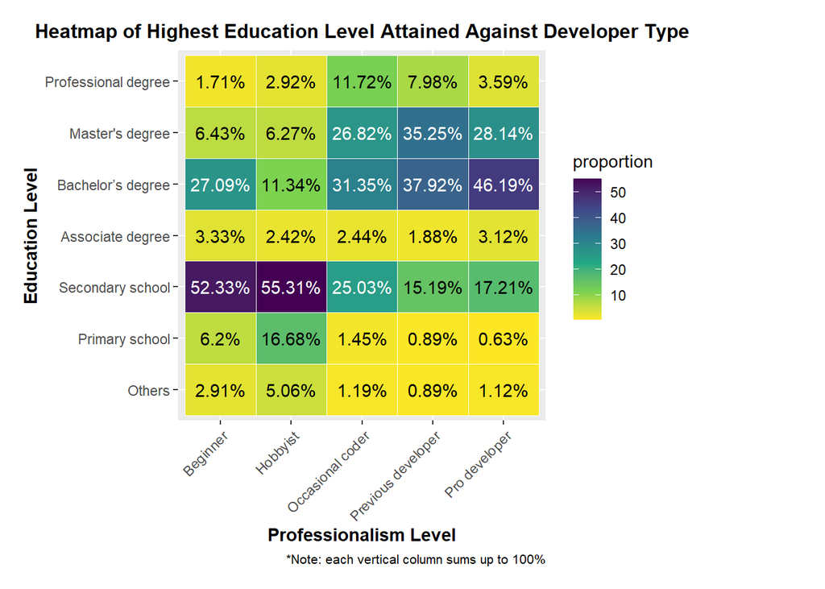

```r
data2 <- data %>%
  group_by(main_branch) %>%
  count(ed_level) %>%
  mutate(prob = round(n * 100/sum(n), 2))

ggplot(data2, aes(x = main_branch, y = ed_level, fill = prob)) +
  geom_tile(color = "white") +
  scale_fill_viridis_c(option = "viridis", direction = -1) +
  geom_text(data = data2, aes(label = str_c(prob, "%"), color = ifelse(prob > 25, "white", "black"))) +
  labs(y = "Education Level", x = "Professionalism Level",
       title = "Heatmap of Highest Education Level Attained Against Developer Type",
       caption = "*Note: each vertical column sums up to 100%",
       fill = "proportion") +
  guides(color = "none")+
  scale_color_manual(values = c("black" = "black", "white" = "white")) +
  theme(plot.title = element_text(hjust = 0.5, face = "bold", size = 12),
        axis.text.x = element_text(angle = 45, hjust = 1),
        plot.caption = element_text(hjust = 1, size = 8),
        axis.title.x = element_text(face = "bold"),
        axis.title.y = element_text(face = "bold"),
        plot.margin = unit(c(0.5, 3.5, 0.5, 0.5), "cm"))
```

### Plot 3: Professional vs. Non-Professional Views on AI as a Threat to Jobs

This plot explores the `ai_threat` variable against the `main_branch` variable and aims to see if one’s perspective on if AI is a threat to one’s jobs determines whether they are a developer or not. Participants were asked to choose one of three responses (Yes, No, or Unsure) to the question on `ai_threat`. We believe a **barplot** with the positions of bars (correlating to each response) dodged will help us visualise the proportions of developers who believe, do not believe, or are unsure of if AI is a threat to their jobs across the different levels of professionalism identified in the `main_branch` variable. We decided to explore the **proportion** of people that responded for each `main_branch` instead of the absolute value as a signficant number of respondents to this question were **Pro Developers**. Thus, using absolute values may shrink the other `main_branch` level bar heights, making comparisons between the bars trivial and difficult to infer from.

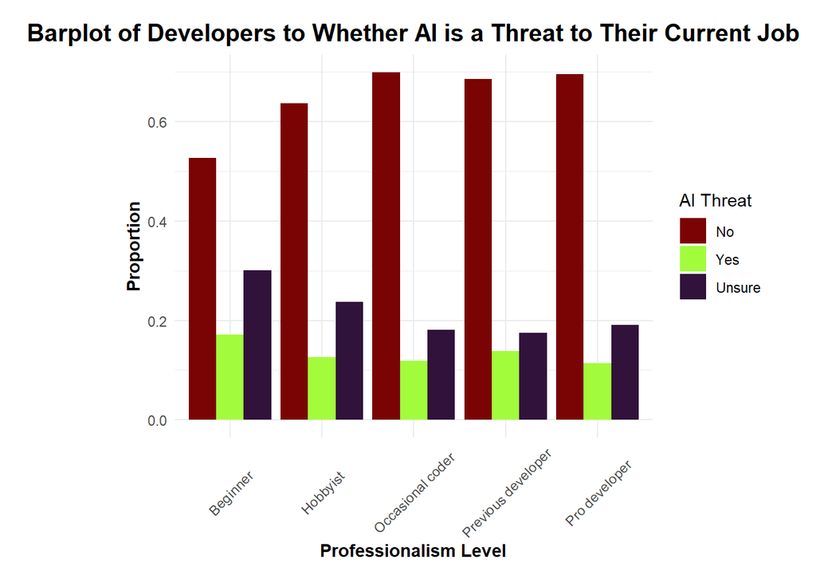

```r
data3 <- data %>%
  count(main_branch, ai_threat) %>%
  group_by(main_branch) %>%
  mutate(prop = n / sum(n)) %>%
  ungroup()

ggplot(data3) +
  geom_col(aes(x = main_branch, y = prop, fill = ai_threat), position = "dodge") +
  scale_fill_viridis(discrete = TRUE, option="H", direction=-1)+
  labs(title="Barplot of Developers to Whether AI is a Threat to Their Current Job",
       y = "Proportion", fill = "AI Threat", x = "Professionalism Level")+
  theme_minimal() +
  theme(plot.title = element_text(hjust = 0.5, face = "bold", size = 15),
        axis.text.x = element_text(angle = 45, vjust=0.5),
        axis.title.x = element_text(face = "bold"),
        axis.title.y = element_text(face = "bold"),
        plot.margin = unit(c(0.5, 1, 0.5, 2.75), "cm"))
```